# Solution Lecture 3

Dr. Thomas Pollet, Northumbria University (thomas.pollet@northumbria.ac.uk)

2020-09-23 | disclaimer

## Exercise 3: instructions.

Using last week’s Salaries dataset, test the assumptions for an ANOVA with monthly salary as dependent variable and academic rank as independent variable.

Conduct an ANOVA with the appropriate post-hoc tests. What do you conclude?

Conduct an alternative non-parametric test to the ANOVA. What do you conclude?

Conduct an ANCOVA with gender as factor, and years since Ph.D. as covariate. What do you conclude?

Load the iris dataset, it is part of the [datasets package](https://rstudio-pubs-static.s3.amazonaws.com/204918_d5ccf842cbc540e78b3d6d3287e6ad38.html).

It is a famous dataset with measurements of 3 species of iris flowers.

Run the MANOVA. What do you conclude? Write up the result as you would do for a paper?

BONUS: Plot one of the results from your analyses on the salaries database.

BONUS: Conduct a follow up analysis or plot for the MANOVA.

## Load the salaries database

```r
setwd("~/Dropbox/Teaching_MRes_Northumbria/Lecture3")
require(carData)
salaries<-carData::Salaries
require(dplyr)
salaries<- salaries %>% mutate(monthly_salary=salary/9)
```

## Check assumptions

### Normality

We perform a visual check here. See the slides for (inferior?) alternatives

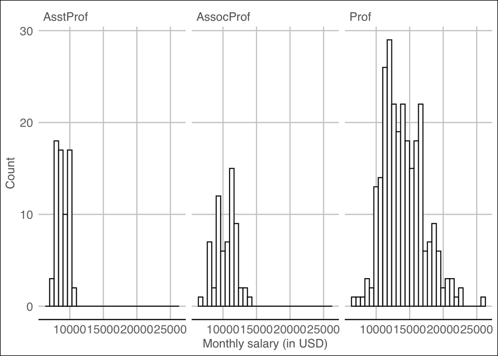

```r
require(ggplot2)
require(ggthemes)
plot_hist <- ggplot(salaries, aes(x=monthly_salary))
plot_hist <- plot_hist+ geom_histogram(colour = "black", fill = "white") + facet_wrap(~rank) + theme_gdocs(12) + xlab("Monthly salary (in USD)") + ylab("Count")
plot_hist
```

More or less OK, perhaps some deviations from normality with the asst. prof group. There is perhaps one extreme case in the prof. group who earns more than 25k USD a month!

### Homogeneity of variance

Many options exist but went with Levene’s test.

```r
require(car)
leveneTest(monthly_salary ~ rank, data=salaries)
```

```
## Levene's Test for Homogeneity of Variance (center = median)
##        Df F value    Pr(>F)
## group   2  38.711 4.477e-16 ***
##       394
## ---
## Signif. codes:  0 '***' 0.001 '**' 0.01 '*' 0.05 '.' 0.1 ' ' 1
```

The assumption for homogeneity of variances is violated (Levene’s test: *F*(2,394) = 38.71, *p*< .0001).

## ANOVA

```r
require(ez)
salaries$ID<- c(1:(NROW(salaries))) # This makes an ID variable
EZ_ANOVA1<-ezANOVA(salaries, dv=monthly_salary, wid=ID, between=rank, detailed=TRUE)
```

```
## Coefficient covariances computed by hccm()
```

```r
EZ_ANOVA1
```

```
## $ANOVA
##   Effect DFn DFd        SSn        SSd        F            p p<.05       ges
## 1   rank   2 394 1768293404 2716899714 128.2174 1.293048e-43     * 0.3942513
##
## $`Levene's Test for Homogeneity of Variance`
##   DFn DFd       SSn       SSd        F            p p<.05
## 1   2 394 194134938 987948286 38.71112 4.476856e-16     *
```

A one-way ANOVA showed a significant effect of academic rank on monthly salary, *F*(2, 394) = 128.22, *p* < .0001, $\eta^2_g$ = .39.

## Alternative (non-parametric) test.

Many different options (see lecture slides). I went with a medians test.

```r
require(WRS2)
# WRS, ANOVA for Medians. (note iter=)
med1way(monthly_salary ~ rank, data=salaries, iter=10000)
```

```
## Call:
## med1way(formula = monthly_salary ~ rank, data = salaries, iter = 10000)
##
## Test statistic F: 96.3811
## Critical value: 2.8435
## p-value: 0
```

```r
# analysis of Medians leads to same conclusion.
require(dplyr)
grouped<-group_by(salaries, rank)
grouped %>% summarise(median= median(monthly_salary))
```

```
## # A tibble: 3 x 2
##   rank      median
##   <fct>      <dbl>
## 1 AsstProf   8867.
## 2 AssocProf 10625.
## 3 Prof      13702.
```

A median test showed that the medians differed significantly by academic rank (Test= 96.38, *p*<.0001). The medians showed that Assistant professors ($8867) earned least, followed by Associate Professors ($10625), and full Professors earned most ($13,702).

## ANCOVA

(Note: assumptions not tested here)

```r
require(car)
require(compute.es)
Ancova<-lm(monthly_salary~sex+yrs.since.phd, contrasts=list(sex=contr.sum), data=salaries)
Anova(Ancova, type="III")
```

```
## Anova Table (Type III tests)
##
## Response: monthly_salary
##                   Sum Sq  Df  F value  Pr(>F)
## (Intercept)   7453959093   1 800.1813 < 2e-16 ***
## sex             26656153   1   2.8615 0.09151 .
## yrs.since.phd  728776994   1  78.2341 < 2e-16 ***
## Residuals     3670243101 394
## ---
## Signif. codes:  0 '***' 0.001 '**' 0.01 '*' 0.05 '.' 0.1 ' ' 1
```

A one-way ANCOVA examined the effect of gender on monthly salary whilst controlling for the number of years since Ph.D. There was no statistically significant effect of gender, *F*(1,394)=2.86, *p*=.092. However, the effect of the covariate, years since Ph.D., was significant, *F*(1,394)=78.23, *p*<.0001.

## MANOVA

### Load the iris dataset / histograms.

I previously have made an error in the instructions and had previously run everything with *width* rather than *length*

```r
require(datasets) # not super-necessary as datasets is part of base r
require(skimr)
iris<-datasets::iris
skim(iris)
```

Data summary

| Name | iris |
| --- | --- |
| Number of rows | 150 |
| Number of columns | 5 |
| _______________________ |  |
| Column type frequency: |  |
| factor | 1 |
| numeric | 4 |
| ________________________ |  |
| Group variables | None |

**Variable type: factor**

| skim_variable | n_missing | complete_rate | ordered | n_unique | top_counts |
| --- | --- | --- | --- | --- | --- |
| Species | 0 | 1 | FALSE | 3 | set: 50, ver: 50, vir: 50 |

**Variable type: numeric**

| skim_variable | n_missing | complete_rate | mean | sd | p0 | p25 | p50 | p75 | p100 | hist |
| --- | --- | --- | --- | --- | --- | --- | --- | --- | --- | --- |
| Sepal.Length | 0 | 1 | 5.84 | 0.83 | 4.3 | 5.1 | 5.80 | 6.4 | 7.9 | ▆▇▇▅▂ |
| Sepal.Width | 0 | 1 | 3.06 | 0.44 | 2.0 | 2.8 | 3.00 | 3.3 | 4.4 | ▁▆▇▂▁ |
| Petal.Length | 0 | 1 | 3.76 | 1.77 | 1.0 | 1.6 | 4.35 | 5.1 | 6.9 | ▇▁▆▇▂ |
| Petal.Width | 0 | 1 | 1.20 | 0.76 | 0.1 | 0.3 | 1.30 | 1.8 | 2.5 | ▇▁▇▅▃ |

```r
# summarytools also prints nice overview.
#??summarytools
require(summarytools)
dfSummary(iris)
```

```
## Data Frame Summary
## iris
## Dimensions: 150 x 5
## Duplicates: 1
##
## ----------------------------------------------------------------------------------------------------------------------
## No   Variable        Stats / Values           Freqs (% of Valid)   Graph                            Valid    Missing
## ---- --------------- ------------------------ -------------------- -------------------------------- -------- ---------
## 1    Sepal.Length    Mean (sd) : 5.8 (0.8)    35 distinct values     . . : :                        150      0
##      [numeric]       min < med < max:                                : : : :                        (100%)   (0%)
##                      4.3 < 5.8 < 7.9                                 : : : : :
##                      IQR (CV) : 1.3 (0.1)                            : : : : :
##                                                                    : : : : : : : :
##
## 2    Sepal.Width     Mean (sd) : 3.1 (0.4)    23 distinct values           :                        150      0
##      [numeric]       min < med < max:                                      :                        (100%)   (0%)
##                      2 < 3 < 4.4                                         . :
##                      IQR (CV) : 0.5 (0.1)                              : : : :
##                                                                    . . : : : : : :
##
## 3    Petal.Length    Mean (sd) : 3.8 (1.8)    43 distinct values   :                                150      0
##      [numeric]       min < med < max:                              :         . :                    (100%)   (0%)
##                      1 < 4.3 < 6.9                                 :         : : .
##                      IQR (CV) : 3.5 (0.5)                          : :       : : : .
##                                                                    : :   . : : : : : .
##
## 4    Petal.Width     Mean (sd) : 1.2 (0.8)    22 distinct values   :                                150      0
##      [numeric]       min < med < max:                              :                                (100%)   (0%)
##                      0.1 < 1.3 < 2.5                               :       . .   :
##                      IQR (CV) : 1.5 (0.6)                          :       : :   :   .
##                                                                    : :   : : : . : : :
##
## 5    Species         1. setosa                50 (33.3%)           IIIIII                           150      0
##      [factor]        2. versicolor            50 (33.3%)           IIIIII                           (100%)   (0%)
##                      3. virginica             50 (33.3%)           IIIIII
## ----------------------------------------------------------------------------------------------------------------------
```

### histograms.

Visual inspection of normality. This time with the ‘few theme’.

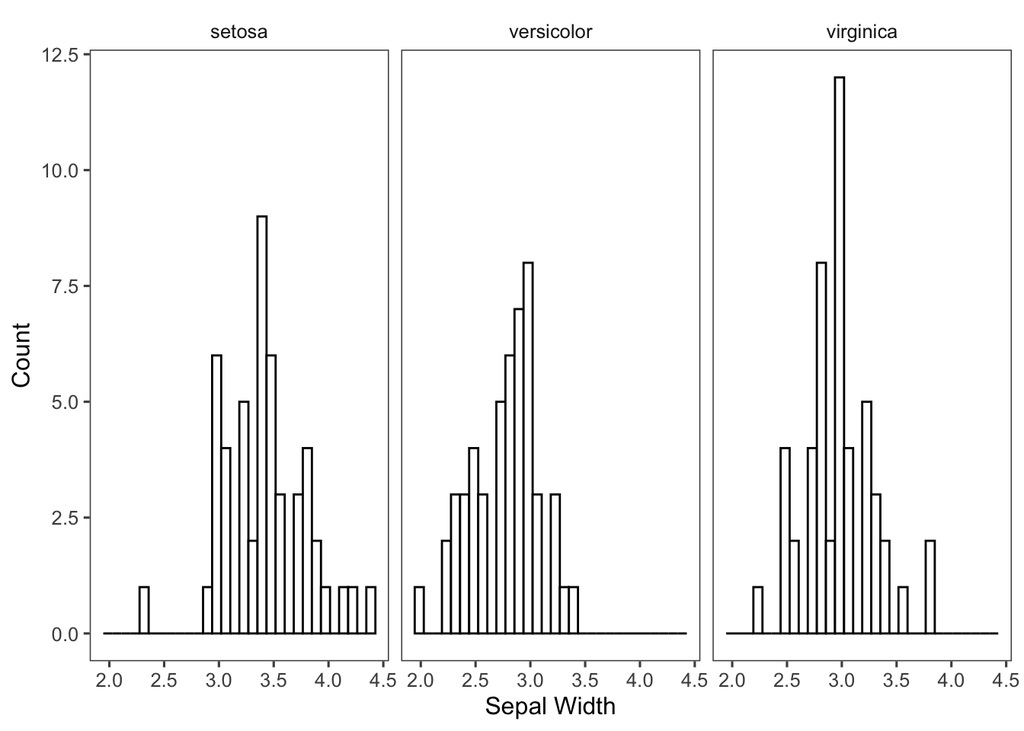

```r
require(ggplot2)
require(ggthemes)
plot_hist_sepal <- ggplot(iris, aes(x=Sepal.Width))
plot_hist_sepal <- plot_hist_sepal+ geom_histogram(colour = "black", fill = "white") + facet_wrap(~Species) + theme_few(12) + xlab("Sepal Width") + ylab("Count")
plot_hist_sepal
```

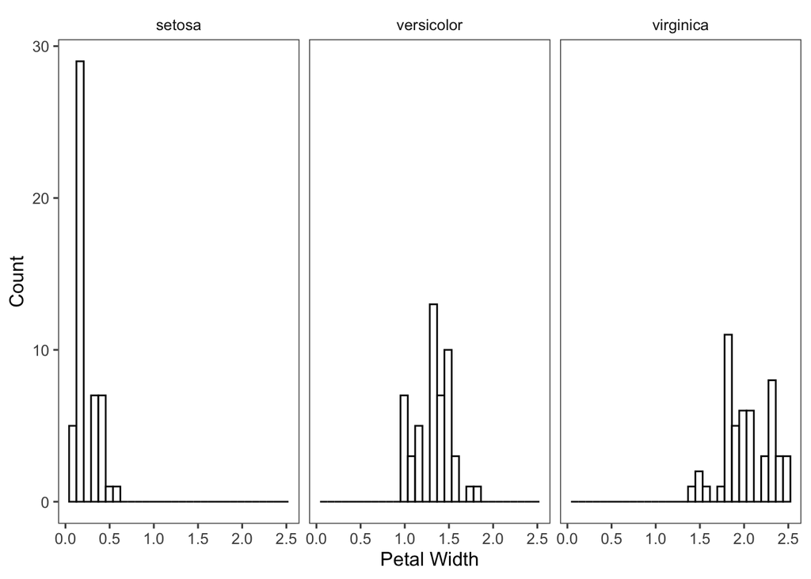

```r
plot_hist_petal <- ggplot(iris, aes(x=Petal.Width))
plot_hist_petal <- plot_hist_petal+ geom_histogram(colour = "black", fill = "white") + facet_wrap(~Species) + theme_few(12) + xlab("Petal Width") + ylab("Count")
plot_hist_petal
```

This seems generally fine for sepal width but perhaps some issues for petal width. As a follow-up one could consider bootstrapping the results.

Here I do the test for length rather than width.

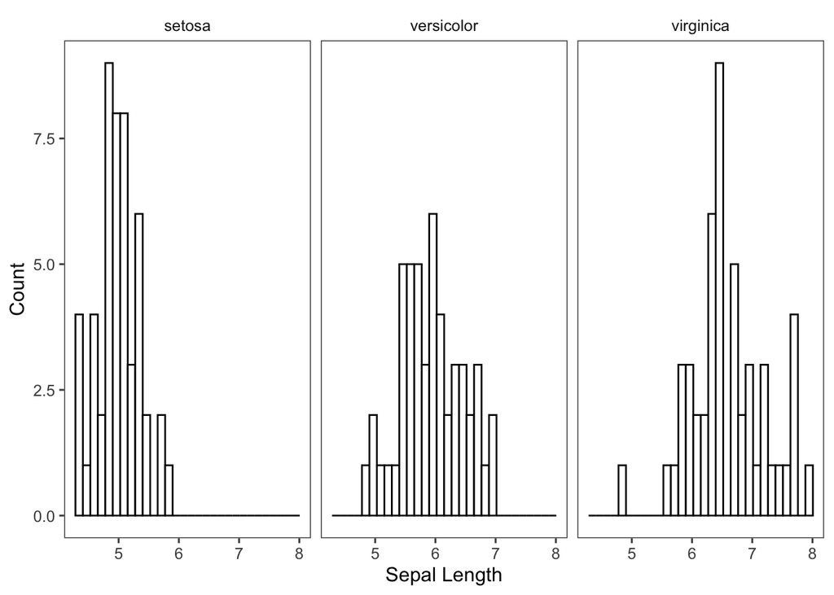

```r
require(ggplot2)
require(ggthemes)
plot_hist_sepal_l <- ggplot(iris, aes(x=Sepal.Length))
plot_hist_sepal_l <- plot_hist_sepal_l+ geom_histogram(colour = "black", fill = "white") + facet_wrap(~Species) + theme_few(12) + xlab("Sepal Length") + ylab("Count")
plot_hist_sepal_l
```

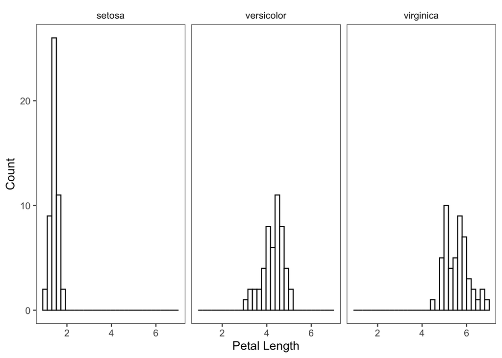

```r
plot_hist_petal_l <- ggplot(iris, aes(x=Petal.Length))
plot_hist_petal_l <- plot_hist_petal_l+ geom_histogram(colour = "black", fill = "white") + facet_wrap(~Species) + theme_few(12) + xlab("Petal Length") + ylab("Count")
plot_hist_petal_l
```

### Multivariate normality

mardiaTest is deprecated as a function(). So now updated with ‘mvn’

```r
require(dplyr)
multivariatenorm<- iris %>% select(c(Sepal.Width,Petal.Width))
require(MVN)
mvn(multivariatenorm)
```

```
## $multivariateNormality
##              Test        Statistic             p value Result
## 1 Mardia Skewness 15.3293889575871 0.00406460864270206     NO
## 2 Mardia Kurtosis -1.6819800923978  0.0925727002920151    YES
## 3             MVN             <NA>                <NA>     NO
##
## $univariateNormality
##           Test    Variable Statistic   p value Normality
## 1 Shapiro-Wilk Sepal.Width    0.9849  0.1012      YES
## 2 Shapiro-Wilk Petal.Width    0.9018  <0.001      NO
##
## $Descriptives
##               n     Mean   Std.Dev Median Min Max 25th 75th       Skew
## Sepal.Width 150 3.057333 0.4358663    3.0 2.0 4.4  2.8  3.3  0.3126147
## Petal.Width 150 1.199333 0.7622377    1.3 0.1 2.5  0.3  1.8 -0.1009166
##               Kurtosis
## Sepal.Width  0.1387047
## Petal.Width -1.3581792
```

The assumption of multivariate normality is violated.

Let us look at length. (Now with a Q-Q plot, also note other options for making figures).

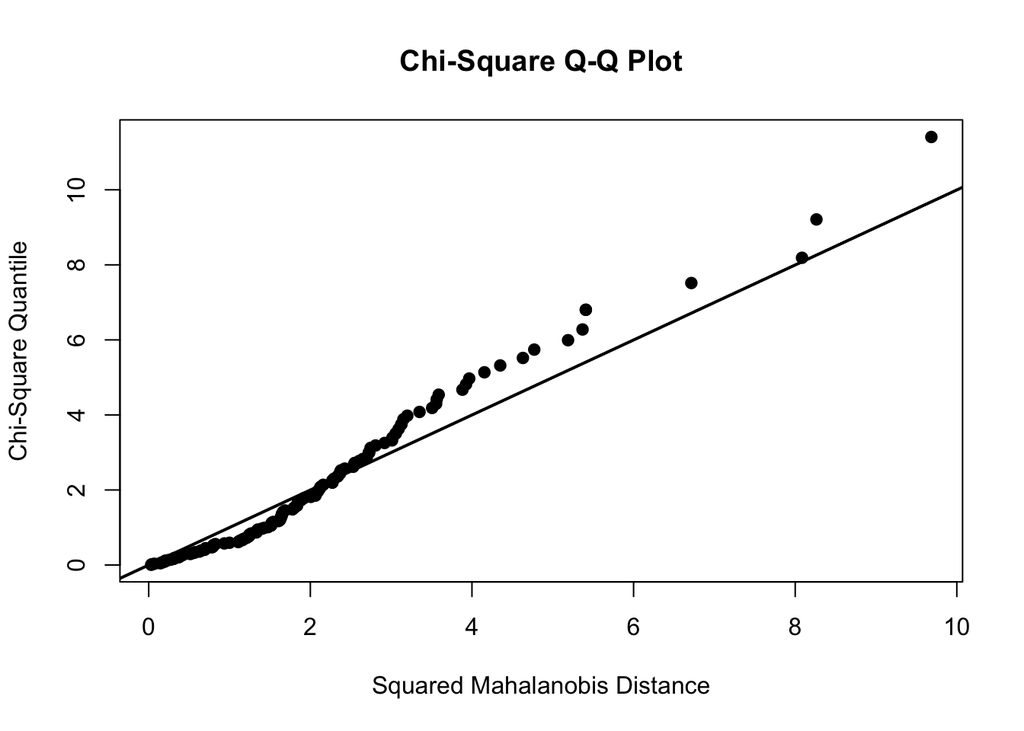

```
## $multivariateNormality
##              Test         Statistic            p value Result
## 1 Mardia Skewness  12.6691153958323 0.0130109939772815     NO
## 2 Mardia Kurtosis -2.29367143373775  0.021809378795248     NO
## 3             MVN              <NA>               <NA>     NO
##
## $univariateNormality
##           Test     Variable Statistic   p value Normality
## 1 Shapiro-Wilk Sepal.Length    0.9761  0.0102      NO
## 2 Shapiro-Wilk Petal.Length    0.8763  <0.001      NO
##
## $Descriptives
##                n     Mean   Std.Dev Median Min Max 25th 75th       Skew
## Sepal.Length 150 5.843333 0.8280661   5.80 4.3 7.9  5.1  6.4  0.3086407
## Petal.Length 150 3.758000 1.7652982   4.35 1.0 6.9  1.6  5.1 -0.2694109
##                Kurtosis
## Sepal.Length -0.6058125
## Petal.Length -1.4168574
```

```r
require(dplyr)
multivariatenorm2<- iris %>% select(c(Sepal.Length,Petal.Length))
require(MVN)
mvn(multivariatenorm2, multivariatePlot = "qq")
```

### Homogeneity of variance

```r
require(car)
leveneTest(Petal.Width~Species, data= iris)
```

```
## Levene's Test for Homogeneity of Variance (center = median)
##        Df F value    Pr(>F)
## group   2  19.892 2.261e-08 ***
##       147
## ---
## Signif. codes:  0 '***' 0.001 '**' 0.01 '*' 0.05 '.' 0.1 ' ' 1
```

```r
leveneTest(Sepal.Width~Species, data= iris)
```

```
## Levene's Test for Homogeneity of Variance (center = median)
##        Df F value Pr(>F)
## group   2  0.5902 0.5555
##       147
```

Levene’s tests showed that the assumption of homogeneity of variances is not violated for sepal width, *F*(2,147) = 0.59, *p*= .56) but it is violated for petal width (*F*(2,147) = 19.89, *p*< .00001).

Now let’s do it for length.

```r
require(car)
leveneTest(Petal.Length~Species, data= iris)
```

```
## Levene's Test for Homogeneity of Variance (center = median)
##        Df F value    Pr(>F)
## group   2   19.48 3.129e-08 ***
##       147
## ---
## Signif. codes:  0 '***' 0.001 '**' 0.01 '*' 0.05 '.' 0.1 ' ' 1
```

```r
leveneTest(Sepal.Length~Species, data= iris)
```

```
## Levene's Test for Homogeneity of Variance (center = median)
##        Df F value   Pr(>F)
## group   2  6.3527 0.002259 **
##       147
## ---
## Signif. codes:  0 '***' 0.001 '**' 0.01 '*' 0.05 '.' 0.1 ' ' 1
```

Levene’s tests showed that the assumption of homogeneity of variances is violated for both sepal length, *F*(2,147) = 6.35, *p*= .002) and for petal length (*F*(2,147) = 19.48, *p*< .00001).

### Box M test

```r
require(heplots)
boxM(multivariatenorm, iris$Species)
```

```
##
##  Box's M-test for Homogeneity of Covariance Matrices
##
## data:  multivariatenorm
## Chi-Sq (approx.) = 51.794, df = 6, p-value = 2.051e-09
```

The Box M test is significant (*p*<.00001). (Note that it is very easily significant, and you should be aware of this. Likely many researchers would still proceed.).

Let’s look at length.

```r
require(heplots)
boxM(multivariatenorm2, iris$Species)
```

```
##
##  Box's M-test for Homogeneity of Covariance Matrices
##
## data:  multivariatenorm2
## Chi-Sq (approx.) = 58.376, df = 6, p-value = 9.617e-11
```

The Box M test is significant (*p*<.00001). (Note that it is very easily significant, and you should be aware of this. Likely many researchers would still proceed.)

### MANOVA

```r
Manovamodel <- manova(cbind(Sepal.Width,Petal.Width) ~ Species, data = iris)
summary(Manovamodel)
```

```
##            Df Pillai approx F num Df den Df    Pr(>F)
## Species     2 1.1438   98.181      4    294 < 2.2e-16 ***
## Residuals 147
## ---
## Signif. codes:  0 '***' 0.001 '**' 0.01 '*' 0.05 '.' 0.1 ' ' 1
```

A MANOVA was conducted with two dependent variables (Petal width and Sepal width) and Species as the between-subject factor. A statistically significant effect was found (Pillai’s Trace= 1.14, *F*(4,294)=98.18, *p*<.0001).

So, the petal width and sepal widths differ between the species of iris flowers.

Now again for length,… .

```r
Manovamodel <- manova(cbind(Sepal.Length,Petal.Length) ~ Species, data = iris)
summary(Manovamodel)
```

```
##            Df Pillai approx F num Df den Df    Pr(>F)
## Species     2 0.9885   71.829      4    294 < 2.2e-16 ***
## Residuals 147
## ---
## Signif. codes:  0 '***' 0.001 '**' 0.01 '*' 0.05 '.' 0.1 ' ' 1
```

A MANOVA was conducted with two dependent variables (Petal Length and Sepal Length) and Species as the between-subject factor. A statistically significant effect was found (Pillai’s Trace= 0.99, *F*(4,294)=71.83, *p*<.0001).

## BONUS: Plot one of the results from the analyses salaries database.

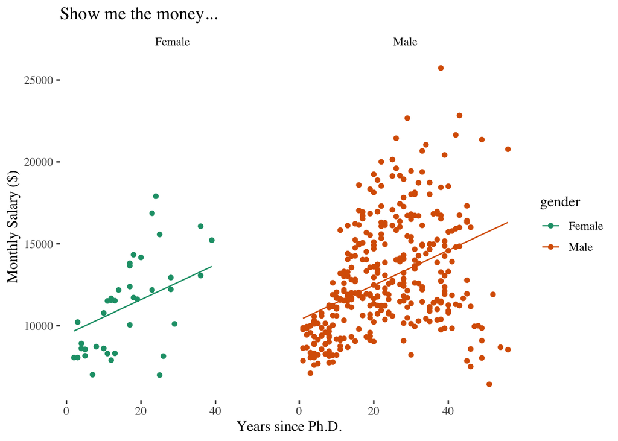

```r
require(ggplot2)
require(ggthemes)
require(RColorBrewer)
# get the model predictions
pred=predict(Ancova)
# rename sex to gender
colnames(salaries)[5] <-"gender"
## plot
ggplot(data = cbind(salaries, pred),
    aes(yrs.since.phd, monthly_salary, color=gender)) + geom_point() +
    facet_grid(. ~ gender) + geom_line(aes(y=pred)) + scale_colour_brewer(palette = "Dark2") + labs(x="Years since Ph.D.", y="Monthly Salary ($)",
       title="Show me the money...") +
  theme_tufte(12)
```

## BONUS: Follow up analyses MANOVA

```r
require(ez)
iris$ID<- c(1:(NROW(iris))) # This makes an ID variable
EZ_ANOVA_Petal<-ezANOVA(iris, dv=Petal.Width, wid=ID, between=Species, detailed=TRUE)
```

```
## Coefficient covariances computed by hccm()
```

```r
EZ_ANOVA_Petal
```

```
## $ANOVA
##    Effect DFn DFd      SSn    SSd        F            p p<.05       ges
## 1 Species   2 147 80.41333 6.1566 960.0071 4.169446e-85     * 0.9288829
##
## $`Levene's Test for Homogeneity of Variance`
##   DFn DFd       SSn    SSd        F           p p<.05
## 1   2 147 0.6421333 2.3726 19.89244 2.26052e-08     *
```

```r
EZ_ANOVA_Sepal<-ezANOVA(iris, dv=Sepal.Width, wid=ID, between=Species, detailed=TRUE)
```

```
## Coefficient covariances computed by hccm()
```

```r
EZ_ANOVA_Sepal
```

```
## $ANOVA
##    Effect DFn DFd      SSn    SSd        F            p p<.05       ges
## 1 Species   2 147 11.34493 16.962 49.16004 4.492017e-17     * 0.4007828
##
## $`Levene's Test for Homogeneity of Variance`
##   DFn DFd        SSn  SSd         F         p p<.05
## 1   2 147 0.05693333 7.09 0.5902116 0.5555179
```

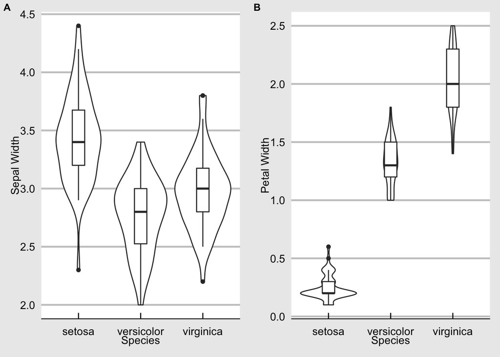

```r
# Make a graph
require(ggplot2)
require(ggthemes)
require(cowplot)
violinplot<-ggplot(iris, aes(x = Species, y = Sepal.Width)) + geom_violin() + geom_boxplot(width = 0.2) + ylab("Sepal Width") + theme_economist_white(12)
violinplot2<-ggplot(iris, aes(x = Species, y = Petal.Width)) + geom_violin() + geom_boxplot(width = 0.2) + ylab("Petal Width") + theme_economist_white(12)
plot_grid(violinplot,violinplot2, labels=c('A', 'B'), label_size= 10, align="h")
```

```r
ggsave("violinplot_panelled.pdf", width= 250, height=250, units="mm")
```

The graph shows that setosa has narrower petals but wider sepals. You could run follow up tests to examine the significance between species in terms of width.

Now let’s do it for length.

```r
require(ez)
iris$ID<- c(1:(NROW(iris))) # This makes an ID variable
EZ_ANOVA_Petal_l<-ezANOVA(iris, dv=Petal.Length, wid=ID, between=Species, detailed=TRUE)
```

```
## Coefficient covariances computed by hccm()
```

```r
EZ_ANOVA_Petal_l
```

```
## $ANOVA
##    Effect DFn DFd      SSn     SSd        F            p p<.05       ges
## 1 Species   2 147 437.1028 27.2226 1180.161 2.856777e-91     * 0.9413717
##
## $`Levene's Test for Homogeneity of Variance`
##   DFn DFd      SSn     SSd        F            p p<.05
## 1   2 147 2.678533 10.1062 19.48034 3.128757e-08     *
```

```r
EZ_ANOVA_Sepal_l<-ezANOVA(iris, dv=Sepal.Length, wid=ID, between=Species, detailed=TRUE)
```

```
## Coefficient covariances computed by hccm()
```

```r
EZ_ANOVA_Sepal_l
```

```
## $ANOVA
##    Effect DFn DFd      SSn     SSd        F            p p<.05       ges
## 1 Species   2 147 63.21213 38.9562 119.2645 1.669669e-31     * 0.6187057
##
## $`Levene's Test for Homogeneity of Variance`
##   DFn DFd    SSn     SSd       F           p p<.05
## 1   2 147 1.2828 14.8418 6.35272 0.002258528     *
```

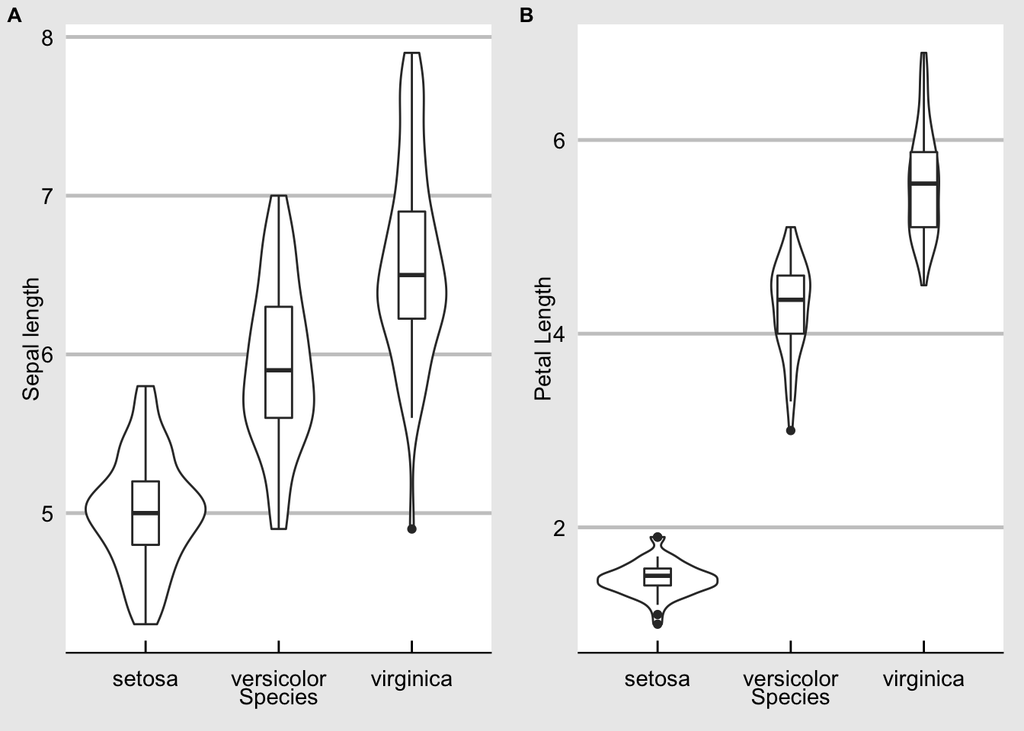

```r
# Make a graph
require(ggplot2)
require(ggthemes)
require(cowplot)
violinplot_l<-ggplot(iris, aes(x = Species, y = Sepal.Length)) + geom_violin() + geom_boxplot(width = 0.2) + ylab("Sepal length") + theme_economist_white(12)
violinplot2_l<-ggplot(iris, aes(x = Species, y = Petal.Length)) + geom_violin() + geom_boxplot(width = 0.2) + ylab("Petal Length") + theme_economist_white(12)
plot_grid(violinplot_l,violinplot2_l, labels=c('A', 'B'), label_size= 10, align="h")
```

```r
ggsave("violinplot_panelled_length.pdf", width= 250, height=250, units="mm")
```

The graph shows that setosa has smaller petals and smaller sepals than other species. The difference is more pronounced in petals than in sepals. You could run follow up tests to examine the significance between species in terms of Sepals.

### The END

[figure not shown]